# Ejemplo-Missing-Data

Felipe Ortega

23/03/2015

# Introducción

Uno de los aspectos más importantes a la hora de trabajar con grandes volúmenes de datos es el tratamiento de datos incompletos o incorrectos. A veces, la omisión de datos importantes o la inclusión de valores erróneos en nuestros cálculos pueden dar al traste con los esfuerzos invertidos en nuestro análisis.

Una de las formas más evidentes para comprobar la existencia de datos erróneos o casos incompletos es inspeccionar la salida del comando `summary()` en R.

```r
summary(airquality)
```

```
##      Ozone           Solar.R           Wind             Temp
##  Min.   :  1.00   Min.   :  7.0   Min.   : 1.700   Min.   :56.00
##  1st Qu.: 18.00   1st Qu.:115.8   1st Qu.: 7.400   1st Qu.:72.00
##  Median : 31.50   Median :205.0   Median : 9.700   Median :79.00
##  Mean   : 42.13   Mean   :185.9   Mean   : 9.958   Mean   :77.88
##  3rd Qu.: 63.25   3rd Qu.:258.8   3rd Qu.:11.500   3rd Qu.:85.00
##  Max.   :168.00   Max.   :334.0   Max.   :20.700   Max.   :97.00
##  NA's   :37       NA's   :7
##      Month            Day
##  Min.   :5.000   Min.   : 1.0
##  1st Qu.:6.000   1st Qu.: 8.0
##  Median :7.000   Median :16.0
##  Mean   :6.993   Mean   :15.8
##  3rd Qu.:8.000   3rd Qu.:23.0
##  Max.   :9.000   Max.   :31.0
##
```

Como podemos observar, algunas de las entradas contienen valores incompletos (*NA*), en particular para las variables `Ozone` (37 casos) y `Solar.R` (7 casos). Esto provoca algunos problemas, por ejemplo a la hora de realizar cálculos o crear modelos.

Si, por ejemplo, queremos calcular los coeficientes de correlación entre los distintos pares de variables de este conjunto obtendremos errores en aquellos casos que involucren variables con valores perdidos:

```r
cor(airquality)
```

```
##         Ozone Solar.R       Wind       Temp        Month          Day
## Ozone       1      NA         NA         NA           NA           NA
## Solar.R    NA       1         NA         NA           NA           NA
## Wind       NA      NA  1.0000000 -0.4579879 -0.178292579  0.027180903
## Temp       NA      NA -0.4579879  1.0000000  0.420947252 -0.130593175
## Month      NA      NA -0.1782926  0.4209473  1.000000000 -0.007961763
## Day        NA      NA  0.0271809 -0.1305932 -0.007961763  1.000000000
```

Una posible solución es eliminar aquellos casos con valores omitidos:

```r
cor(airquality, use="complete.obs")
```

```
##                Ozone     Solar.R        Wind       Temp        Month
## Ozone    1.000000000  0.34834169 -0.61249658  0.6985414  0.142885168
## Solar.R  0.348341693  1.00000000 -0.12718345  0.2940876 -0.074066683
## Wind    -0.612496576 -0.12718345  1.00000000 -0.4971897 -0.194495804
## Temp     0.698541410  0.29408764 -0.49718972  1.0000000  0.403971709
## Month    0.142885168 -0.07406668 -0.19449580  0.4039717  1.000000000
## Day     -0.005189769 -0.05775380  0.04987102 -0.0965458 -0.009001079
##                  Day
## Ozone   -0.005189769
## Solar.R -0.057753801
## Wind     0.049871017
## Temp    -0.096545800
## Month   -0.009001079
## Day      1.000000000
```

Otra opción es eliminar los casos con valores omitidos solo para los calculos de con las variables afectadas, pero utilizar todos los casos para las demás variables que sí que están completas:

```r
cor(airquality, use="pairwise.complete.obs")
```

```
##               Ozone     Solar.R        Wind       Temp        Month
## Ozone    1.00000000  0.34834169 -0.60154653  0.6983603  0.164519314
## Solar.R  0.34834169  1.00000000 -0.05679167  0.2758403 -0.075300764
## Wind    -0.60154653 -0.05679167  1.00000000 -0.4579879 -0.178292579
## Temp     0.69836034  0.27584027 -0.45798788  1.0000000  0.420947252
## Month    0.16451931 -0.07530076 -0.17829258  0.4209473  1.000000000
## Day     -0.01322565 -0.15027498  0.02718090 -0.1305932 -0.007961763
##                  Day
## Ozone   -0.013225647
## Solar.R -0.150274979
## Wind     0.027180903
## Temp    -0.130593175
## Month   -0.007961763
## Day      1.000000000
```

También ocurre en el caso de la creación de modelos. Por ejemplo, cuando efectuamos una regresión lineal para establecer cómo se ve afectada la temperatura recogida en la variable `Temp` en función de `Ozone` y `Solar.R`:

```r
lmodel = lm(Temp ~ Ozone + Solar.R, data=airquality)
summary(lmodel)
```

```
##
## Call:
## lm(formula = Temp ~ Ozone + Solar.R, data = airquality)
##
## Residuals:
##     Min      1Q  Median      3Q     Max
## -21.576  -5.137   1.625   4.741  12.511
##
## Coefficients:
##              Estimate Std. Error t value Pr(>|t|)
## (Intercept) 68.497103   1.528467  44.814  < 2e-16 ***
## Ozone        0.194294   0.020977   9.262 2.22e-15 ***
## Solar.R      0.006039   0.007658   0.789    0.432
## ---
## Signif. codes:  0 '***' 0.001 '**' 0.01 '*' 0.05 '.' 0.1 ' ' 1
##
## Residual standard error: 6.862 on 108 degrees of freedom
##   (42 observations deleted due to missingness)
## Multiple R-squared:  0.4909, Adjusted R-squared:  0.4815
## F-statistic: 52.07 on 2 and 108 DF,  p-value: < 2.2e-16
```

```r
length(airquality$Ozone)
```

```
## [1] 153
```

```r
length(lmodel$fitted)
```

```
## [1] 111
```

# Visualización de valores perdidos/omitidos

Los paquetes `Amelia`, `mice` y `VIM` (Visualization and Imputation of Missing Values) pueden resultar muy útiles para estas labores.

```r
suppressMessages(library(mice))
suppressMessages(library(VIM))
# Obtener patrón de valors NAs
md.pattern(airquality)
```

```
##     Wind Temp Month Day Solar.R Ozone
## 111    1    1     1   1       1     1  0
##  35    1    1     1   1       1     0  1
##   5    1    1     1   1       0     1  1
##   2    1    1     1   1       0     0  2
##        0    0     0   0       7    37 44
```

# Visualización de patrones de aparición de NAs

```r
# Visualización de casos con NAs
aggr(airquality, prop = F, numbers = T)
```

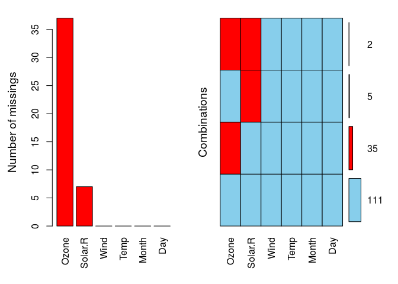

# Asignación múltiple de valores ausentes

Existen diferentes técnicas que permiten asignar valores a los casos con datos omitidos de forma que los resultados que ofrezcan nuestros modelos se vean perjudicados en la menor medida posible. Estas técnicas reciben el nombre de *multiple imputation* en inglés.

La discusión en detalle de estos procedimientos queda fuera del alcance de este laboratorio, pero aquellos interesados en ampliar más información pueden consultar las referencias [1, 2, 3].

# Exploración y transformación de datos

Un paso esencial previo a la realización de cualquier análisis de datos consiste en inspeccionar mediante técnicas de visualización y exploración el aspecto que tienen nuestros datos, en busca de patrones poco habituales, casos fuera de lo corriente, y cualquier otro fenómeno que pueda influir en los resultados de nuestro análisis posterior.

Para este paso nos vamos a ayudar de las funciones proporcionadas por el paquete `car` en R [4].

## Scatterplot

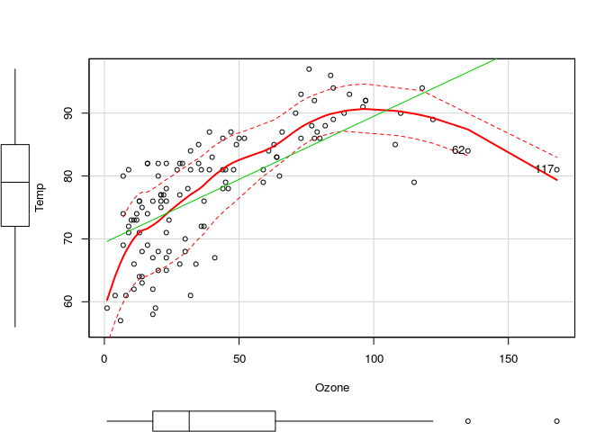

```
##  62 117
##  36  82
```

```r
library(car)
scatterplot(Temp ~ Ozone, data=airquality, id.n=2)
```

## Diagrama de correlaciones (scatterplot matrix)

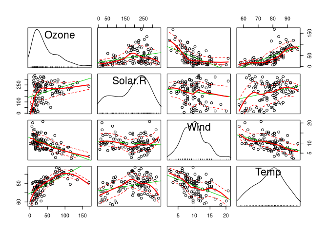

```r
scatterplotMatrix(~ Ozone + Solar.R + Wind + Temp, data=airquality, span=0.6)
```

## Transformación de variables

Existen múltiples alternativas de transformación de variables, incluyendo logaritmos, potencias, inversas y familias de transformaciones, tales como Box-Cox o Yeo-Johnson [4].

De todas ellas, el logaritmo (natural o decimal) es una de las más usuales.

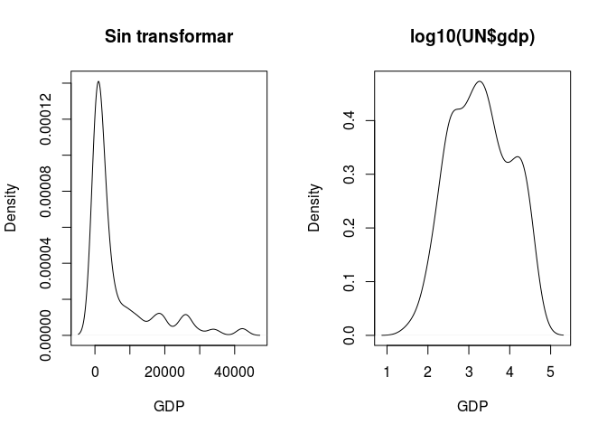

```r
par(mfrow=c(1, 2))
plot(density(UN$gdp, na.rm=T), xlab="GDP", main="Sin transformar")
plot(density(log10(UN$gdp), na.rm=T), xlab="GDP", main="log10(UN$gdp)")
```

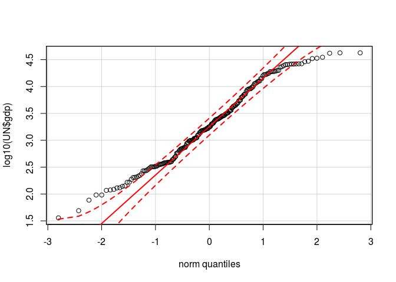

```r
qqPlot(log10(UN$gdp), distribution="norm")
```

# *Wide format* vs. *long format*

Otra tarea muy común en preparación de datos para posteriores análisis es la de descubrir si el modelo o herramienta que pretendemos usar necesita leer los datos en formato *wide* (una fila por caso y varias columnas con los valores de cada parámetro para ese caso) o *long* (varias filas por caso, y una variable categórica que indica a qué parámetro pertenece el valor indicado).

Las bibliotecas de R `tidyr` y `reshape2` pueden resultar útiles para transformar nuestros datos entre estos dos formatos. Veamos un ejemplo [5]:

```r
library(tidyr)
# De wide format a long format: gather()
airquality_long = gather(airquality, variable, measurement, Ozone:Temp)
# Equivalmente, pero más fácil, que la siguiente instrucción
# airquality_long <- melt(airquality, id.vars = c("Month", "Day"))
head(airquality_long)
```

```
##   Month Day variable measurement
## 1     5   1    Ozone          41
## 2     5   2    Ozone          36
## 3     5   3    Ozone          12
## 4     5   4    Ozone          18
## 5     5   5    Ozone          NA
## 6     5   6    Ozone          28
```

```r
tail(airquality_long)
```

```
##     Month Day variable measurement
## 607     9  25     Temp          63
## 608     9  26     Temp          70
## 609     9  27     Temp          77
## 610     9  28     Temp          75
## 611     9  29     Temp          76
## 612     9  30     Temp          68
```

```r
# De long format a wide format: spread()
airquality_wide = spread(airquality_long, variable, measurement)
head(airquality_wide)
```

```
##   Month Day Ozone Solar.R Wind Temp
## 1     5   1    41     190  7.4   67
## 2     5   2    36     118  8.0   72
## 3     5   3    12     149 12.6   74
## 4     5   4    18     313 11.5   62
## 5     5   5    NA      NA 14.3   56
## 6     5   6    28      NA 14.9   66
```

```r
tail(airquality_wide)
```

```
##     Month Day Ozone Solar.R Wind Temp
## 148     9  25    14      20 16.6   63
## 149     9  26    30     193  6.9   70
## 150     9  27    NA     145 13.2   77
## 151     9  28    14     191 14.3   75
## 152     9  29    18     131  8.0   76
## 153     9  30    20     223 11.5   68
```

Existe una hoja de referencia para operaciones de transformación y limpieza de datos disponible en R con `tidyr` y `dplyr` [6].

# Referencias

1. *Advanced Methods for missing data*. R in Action. http://rstudio-pubs-static.s3.amazonaws.com/4625_fa990d611f024ea69e7e2b10dd228fe7.html.
2. Faraway. J. *Linear Models with R*. 2nd Ed. CRC Press, 2014.
3. Harrell, Frank E. *Regression modeling strategies*. Springer Science & Business Media, 2001.
4. Fox, J. and Weisberg, S. An R companion to Applied Regression. 2nd Ed. Sage Publications, 2011.
5. http://www.cookbook-r.com/Manipulating_data/Converting_data_between_wide_and_long_format/
6. http://www.rstudio.com/wp-content/uploads/2015/02/data-wrangling-cheatsheet.pdf